# 7.0. Introduction : Univariate & Bivariate Analysis

Data in statistics is sometimes classified according to how many variables are in a particular study. Depending on the number of variables being looked at, the data might be univariate, bivariate or multivariate.

### Univariate Analysis :

When you conduct a study that looks at a single variable, that study involves univariate data. The example of a univariate data can be considering only height of students in the dataset for study. Univariate analysis is the analysis of one (“uni”) variable. The analysis of univariate data is thus the simplest form of analysis since the information deals with only one quantity that changes. It does not deal with causes or relationships and the main purpose of the analysis is to describe the data and find patterns that exist within it. Some common tools used in Univariate Analysis are measures of central tendencies, measures of dispersion, frequency distributions, bar plot, histogram, pie chart, box-and-whisker plot.

### Bivariate Analysis :

Bivariate data is when you are studying two variables. Example of bivariate data can be Height and Weight of students in a class. Bivariate analysis is the analysis of exactly two variables. The analysis of this type of data deals with causes and relationships and the analysis is done to find out the relationship among the two variables. Some common tools used in Bivariate Analysis are Correlation Coefficients, Regression Analysis, Scatter plots.

**Multivariate analysis** is the analysis of more than two variables. It is similar to bivariate but contains more than one dependent variable. The ways to perform analysis on this data depends on the goals to be achieved.

There may be complex and unknown relationships between the variables in your dataset. It is important to discover and quantify the degree to which variables in your dataset are dependent upon each other. This knowledge can help you better prepare your data to meet the expectations of machine learning algorithms, such as linear regression, whose performance will degrade with the presence of these interdependencies.

# 7.1. Scatter Plots

The most basic way to study relationships between two variables is to use a graph and try to look at the overall pattern and study the deviations from the pattern. A scatterplot is one of the most effective ways of studying the relationship between the graphs. It shows the relationship between two quantitative variables measured on the same observations.

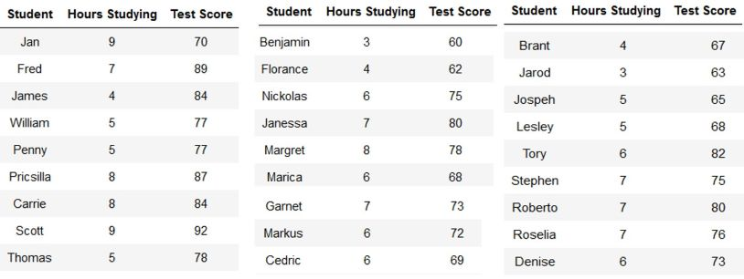

We are interested in the relationship between the two variables. **How is one affected by changes in the other?**

Lets plot a scatter plot in search of the answer to this question.

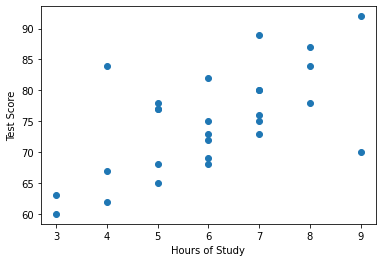

```python
# building dataset
study_hrs =  [9,  7, 4, 5, 5, 8, 8, 9, 5, 3, 4, 6, 7, 8, 6, 7, 6, 6, 4, 3, 5, 5, 6, 7, 7, 7, 6]
test_score = [70,89,84,77,77,87,84,92,78,60,62,75,80,78,68,73,72,69,67,63,65,68,82,75,80,76,73]

#scatter plot
import matplotlib.pyplot as plt

plt.scatter(study_hrs,test_score)
plt.xlabel('Hours of Study')
plt.ylabel('Test Score')
plt.show()
```

At first glance, we can see why we call this a scatter diagram. The pattern of points results because each pair of data from the table above has been recorded as a single point. When we view all these points together, we can visualize the relationship that exists between the two variables.

**You can see that there is a slight upward trend in the data. That is, those that study more tend to do better.**

Scatterplots are useful for identifying general trends in the data as well as identifying points that do not follow the patterns as those data points are always interesting too. For instance, what might one say about Jan, who studied for 9 hours but only received a 70 on the exam? or James, who studied for 4 hours but received 84 ? That would be a data point worth further exploring.

### Exercise :

Plot scatter plot for the following data. What do you think about the relationship between `car_age` and `car_speed`?

```python
#data
car_age = [5,7,8,7,2,17,2,9,4,11,12,9,6]
car_speed = [99,86,87,88,111,86,103,87,94,78,77,85,86]

#scatter plot
```

**Scatterplots are usually studied on three points : the form, direction, and the strength of the association.**

For instance is the form linear or curved? Or is there no pattern at all? In the scatterplot of `Hours of Study` and `Test Score`, there is a slight linear pattern. The direction of the plot is also important. Is it positive, negative or is there no direction at all? Our plot above shows a slight positive direction. Lastly, the scatterplot measures the strength of the relationship. How closely do the points fit the “form”.

Let us take a different example and identify the form, direction, and strength of the relationship between two other measures: `Height` and `Weight`.

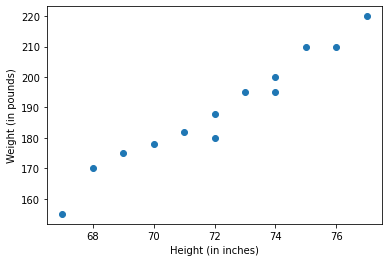

```python
#self made data
height = [ 67, 72, 77, 74, 69, 70, 71, 72, 74, 76, 75, 73, 68] #inches
weight = [155,188,220,195,175,178,182,180,200,210,210,195,170] #pounds

#scatter plot
import matplotlib.pyplot as plt

plt.scatter(height,weight)
plt.xlabel('Height (in inches)')
plt.ylabel('Weight (in pounds)')
plt.show()
```

The form of the relationship is linear for the most part. There are no curves in the plot and there is a clear pattern. The direction is positive; as `Height` go up, the `Weight` tends to rise as well. The strength of the relationship is quite strong.

### Patterns of Data in Scatterplots

Scatterplots are used to analyze patterns in bivariate data. These patterns are described in terms of linearity, slope, and strength.

- **Linearity** refers to whether a data pattern is linear (straight) or nonlinear (curved).

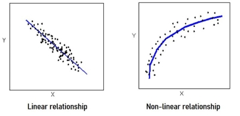

- **Slope** refers to the direction of change in variable Y when variable X gets bigger. If variable Y also increases, the slope is positive; but if variable Y decreases, the slope is negative.

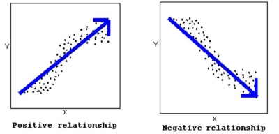

- **Strength** refers to the degree of "scatter" in the plot. If the dots are widely spread, the relationship between variables is weak. If the dots are concentrated around a line, the relationship is strong.

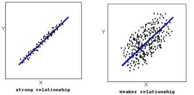

Additionally, scatterplots can reveal unusual features in data sets, such as clusters, gaps, and outliers. The scatterplots below illustrate some common patterns.

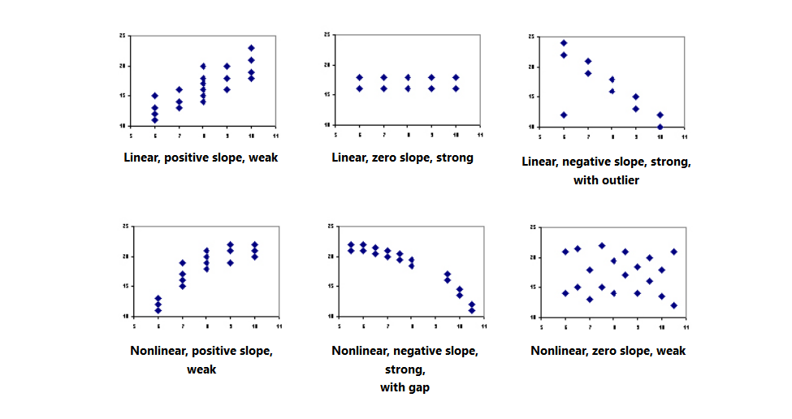

**NOTE:** The pattern in the last example (nonlinear, zero slope, weak) is the pattern that is found when two variables are not related.

# 7.2. Correlation

In the previous example of Height vs Weight, we concluded that "The strength of the relationship between `Height` and `Weight` is quite strong." Quite strong however is a qualitative term that we have selected to describe the strength of the relationship based on our judgment. What would be ideal is to have a statistic, or some quantitative measure, to measure the strength of the relationship.

In this section, you will discover a statistical measure called **Correlation** to quantify the strength of the relationship .

Because visual examinations are largely subjective, we need a more precise and objective measure to define the correlation between the two variables. If the two variables are normally distributed, the standard measure of determining the correlation coefficient, often called **Pearson’s Coefficient of Correlation**, is

$$r =\frac{ \sum_{i=1}^{n}(X_i-\bar{X})(Y_i-\bar{Y}) }{% \sqrt{\sum_{i=1}^{n}(X_i-\bar{X})^2}\sqrt{\sum_{i=1}^{n}(Y_i-\bar{Y})^2}}$$

The population correlation coefficient is,

$$ \rho = \frac{Cov(X,Y)}{\sigma_X \sigma_Y}$$

where,

$Cov(X,Y) = E[(X-\mu_X)(Y-\mu_Y)]$, is the covariance.

$\sigma_X$ is the standard deviation and $\mu_X$ is the population mean of X

$\sigma_Y$ is the standard deviation and $\mu_Y$ is the population mean of Y

Due to this form, Pearson's Correlation Coefficient is also called Product Moment correlation coefficient.

## Covariance

Covariance is a measure of the tendency of two variables to vary together. If we have two series, $X$ and $Y$ , their deviations from the mean are $(x_i-\bar x)$ and $(y_i-\bar y)$ respectively. Where $\bar x$ is the sample mean of $X$ and $\bar y$ is the sample mean of $Y$ . Thus,

**If $X$ and $Y$ vary together, their deviations tend to have the same sign.**

If we multiply them together, the product is positive when the deviations have the same sign and negative when they have the opposite sign. So adding up the products gives a measure of the tendency to vary together.

Covariance is the mean of these products:

$$Cov(X,Y)={1 \over n}{ \sum_{i=1}^{n}(X_i-\bar{X})(Y_i-\bar{Y}) }$$

Covariance is useful in some computations, but it is rarely reported as a summary statistic because it is hard to interpret. Among other problems, its units are the product of the units of $X$ and $Y$ . For example, the covariance of weight and height will be in kilogram-centimeters.

One solution to this problem is to divide the deviations by the standard deviation, i.e., $\frac {(X_i-\bar{X})}{\sigma_X}$ and $\frac {(Y_i-\bar{Y})}{\sigma_Y}$ which yields standard scores, and compute the product of standard scores i.e.,

$$\rho = {1 \over n }{ \sum_{i=1}^{n}{\frac {(X_i-\bar{X})}{\sigma_X}}{\frac {(Y_i-\bar{Y})}{\sigma_Y}} }$$$$\rho = \frac {Cov(X,Y)} {\sigma_X \sigma_Y}$$

This value is called Pearson's correlation. It is easy to compute and easy to interpret. Because standard scores are dimensionless, so is $\rho$.

Before we get into examples, there are several facts about correlation worth pointing out:

- The correlation measures the strength and direction of a linear relationship between two quantitative variables.
- A correlation could be positive, meaning both variables move in the same direction, or negative, meaning that when one variable's value increases, the other variables' values decrease. Correlation can also be neural or zero, meaning that the variables are unrelated.
  - **Positive Correlation:** Both variables change in the same direction.
  - **Neutral Correlation:** No relationship in the change of the variables.
  - **Negative Correlation:** Variables change in opposite directions.
- The correlation is **always between -1 and +1**.
- $r = 1$ indicates a perfect positive correlation, $r = -1$ indicates a perfect negative correlation and $r = 0$ indicates that there is no relationship between the different variables.
- The correlation between $X$ and $Y$ is the same as the correlation between $Y$ and $X$.

**Correlation is best used in variables that demonstrate a linear relationship between each other.** The fit of the data can be visually represented in a scatterplot. Using a scatterplot, we can generally assess the relationship between the variables and determine whether they are correlated or not.

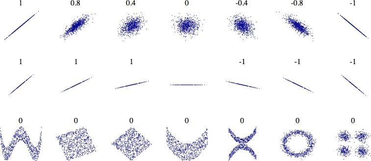

**CAUTION :**

The correlation coefficient only measures linear correlations (“if x goes up, then y generally goes up/down”). It may completely miss out on nonlinear relationships (e.g., “if x is close to zero then y generally goes up”). Note how all the plots of the bottom row have a correlation coefficient equal to zero despite the fact that their axes are clearly not independent: these are examples of nonlinear relationships. Also, the second row shows examples where the correlation coefficient is equal to 1 or –1; notice that this has nothing to do with the slope.

### Correlation does not imply Causation !! Causation means one event is the result of the occurrence of the other event; i.e. there is a causal relationship between the two events. This is also referred to as cause and effect. Simply because we observe a relationship between two variables in a scatter plot or getting a significant $r$ does not always mean that changes in one variable are responsible for changes in the other. This gives rise to the common phrase in statistics that "correlation does not imply causation". It simply means that, because two things correlate does not necessarily mean that one causes the other. As an example, just because a scatter plot shows people in the UK tend to spend more in the shops when it's cold (or Temp. decreases) doesn't mean cold weather causes frenzied high-street spending. A more plausible explanation would be that cold weather tends to coincide with Christmas and the new year sales.

The `pearsonr()` function from `SciPy` can be used to calculate the Pearson’s correlation coefficient between two data samples with the same length.

**NOTE :** This approach uses *Python unpacking* due to the fact that `pearsonr()` returns a tuple of two results.

```python
#data
height = [ 67, 72, 77, 74, 69, 70, 71, 72, 74, 76, 75, 73, 68] #inches
weight = [155,188,220,195,175,178,182,180,200,210,210,195,170] #pounds

#computing Pearson's Correlation Coefficient
from scipy.stats import pearsonr

corr, _ = pearsonr(height, weight)
print('Pearsons correlation:', corr)
```

```
Pearsons correlation: 0.9768736008473002
```

We can see that the two variables are positively correlated and that the correlation is 0.977. This suggests a very high level of correlation as it is a value above 0.5 and close to 1.0.

`corrcoef()` from `numpy` returns the **correlation matrix**, which is a two-dimensional array with the correlation coefficients.

```python
import numpy as np

corr_mat = np.corrcoef(height,weight)
print(corr_mat)
```

```
[[1.        0.9768736]
 [0.9768736 1.       ]]
```

Here’s a simplified version of the correlation matrix you just created:

|  | Height | Weight |
| --- | --- | --- |
| **Height** | 1 | 0.9768736 |
| **Weight** | 0.9768736 | 1 |

Clearly we are getting a very high correlation as the data is made-up for illustration purpose only. Lets try to work around a real life data, where we will also see how to explore relationship between variables in a data frame.

The data we will be using was part of a study at large southwestern university conducted by Willerman et al. (1991) in search of answer to the question : Are the size and weight of your brain indicators of your mental capacity?

```python
import pandas as pd

# reading data
dt = pd.read_csv('./datasets/Brain_Size_Data.csv')
dt.head()
```

|  | Gender | FSIQ | VIQ | PIQ | Weight | Height | MRI_Count |
| --- | --- | --- | --- | --- | --- | --- | --- |
| 0 | Female | 133 | 132 | 124 | 118 | 64.5 | 816932 |
| 1 | Male | 139 | 123 | 150 | 143 | 73.3 | 1038437 |
| 2 | Male | 133 | 129 | 128 | 172 | 68.8 | 965353 |
| 3 | Female | 137 | 132 | 134 | 147 | 65.0 | 951545 |
| 4 | Female | 99 | 90 | 110 | 146 | 69.0 | 928799 |

Column Names and info :

1. **Gender:** Male or Female
2. **FSIQ:** Full Scale IQ scores
3. **VIQ:** Verbal IQ scores
4. **PIQ:** Performance IQ
5. **Weight:** body weight in pounds
6. **Height:** height in inches
7. **MRI_Count:** total pixel Count from the 18 MRI scans

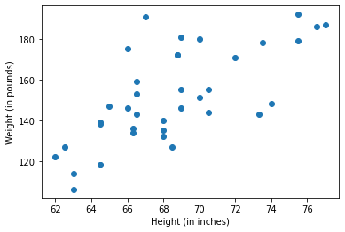

```python
import matplotlib.pyplot as plt
%matplotlib inline

plt.scatter(dt['Height'],dt['Weight'])
plt.xlabel('Height (in inches)')
plt.ylabel('Weight (in pounds)')
plt.show()
```

Let's try to plot it with the help of another visualization library `seaborn`

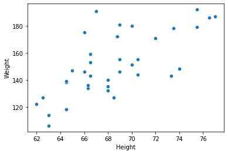

```python
import matplotlib.pyplot as plt
import seaborn as sns
%matplotlib inline

sns.scatterplot(x = 'Height', y = 'Weight', data = dt)
plt.show()
```

We get the exact scatter plot what we obtained with `matplolib` but there are some add-on in `seaborn` scatterplot which are useful. Following is an example where an extra information on `Gender` is also displayed along with the scatter plot.

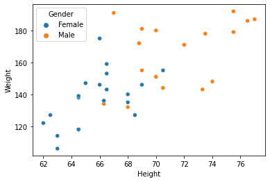

```python
import matplotlib.pyplot as plt
import seaborn as sns
%matplotlib inline

sns.scatterplot(x = 'Height', y = 'Weight', data = dt, hue='Gender')
plt.show()
```

Seaborn’s `jointplot()` displays a relationship between 2 variables (Bivariate) as well as univariate in the margins.

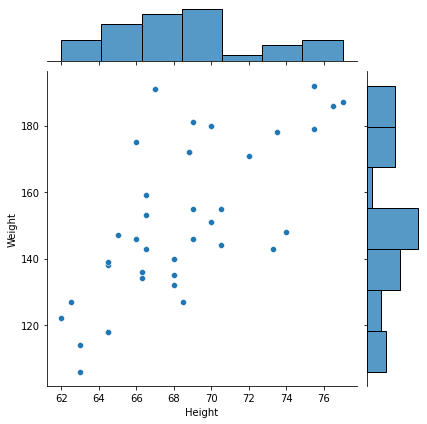

```python
import matplotlib.pyplot as plt
import seaborn as sns
%matplotlib inline

sns.jointplot(x = 'Height', y = 'Weight', data = dt)
plt .show()
```

Here is an example of `jointplot` with 'Line of Best Fit' called Regression Line.

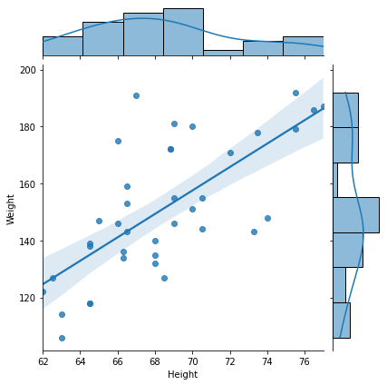

```python
import matplotlib.pyplot as plt
import seaborn as sns
%matplotlib inline

sns.jointplot(x = 'Height', y = 'Weight', data = dt,kind = 'reg')
plt .show()
```

There are many more such visualizations provided by `seaborn`. You can explore them at: https://seaborn.pydata.org/examples/index.html.

**Lets now calculate the correlation coefficient.**

```python
#computing Pearson's Correlation Coefficient
from scipy.stats import pearsonr

corr, _ = pearsonr(dt['Height'], dt['Weight'])
print('Pearsons correlation:', round(corr,2))
```

```
Pearsons correlation: 0.7
```

So from real life data it is confirmed that there is a strong positive relation between `Height` and `Weight`.

How about checking the relationship between `Height` and `FSIQ` i.e., Full Scale IQ. Lets start with a scatter plot first.

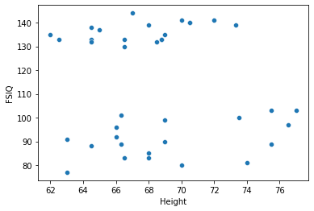

```python
import matplotlib.pyplot as plt
import seaborn as sns
%matplotlib inline

sns.scatterplot(x = 'Height', y = 'FSIQ', data = dt)
plt.show()
```

The scatter plot is not helping much to get to a conlusion. Next is to calculate correlation coefficient.

```python
#computing Pearson's Correlation Coefficient
from scipy.stats import pearsonr

corr, _ = pearsonr(dt['Height'], dt['FSIQ'])
print('Pearsons correlation:', round(corr,2))
```

```
Pearsons correlation: -0.12
```

From this value we can conclude that there is negligible relationhip between `Height` and `FSIQ`.

There are also other types of IQ in the dataset recorded for different categories of tasks and so there are lots of correlation coefficients to calculate. How about getting correlation coeffcient among all the variables in a single view ?

A correlation matrix can be used for this purpose. `.corr()` function from pandas library returns a Correlation Matrix of all numeric variables present in a data frame.

```python
# correlation matrix

corr_mat = dt.corr() #compute correlation for all features in dataset
print(corr_mat)
```

```
               FSIQ       VIQ       PIQ    Weight    Height  MRI_Count
FSIQ       1.000000  0.945114  0.934427 -0.051483 -0.118448   0.333714
VIQ        0.945114  1.000000  0.776020 -0.076088 -0.118976   0.300279
PIQ        0.934427  0.776020  1.000000  0.002512 -0.093156   0.377782
Weight    -0.051483 -0.076088  0.002512  1.000000  0.699614   0.513378
Height    -0.118448 -0.118976 -0.093156  0.699614  1.000000   0.588377
MRI_Count  0.333714  0.300279  0.377782  0.513378  0.588377   1.000000
```

Observe that the diagonal of correlation matrix is 1 as it represent self correlation of variables. Also observe that the values of correlation coefficient for either side of the diagonal (Upper Triangle and Lower Triangle) of the correlation matrix are equal (mirror images) of each other. Recall the statement, "The correlation between $X$ and $Y$ is the same as the correlation between $Y$ and $X$."

# 7.3. Correlation : Multivariate Case

We have already seen in the previous example of Study of Height, Weight and different kinds of IQ that it is possible to create a correlation matrix which displays correlation for all the numeric variables present in dataset. Here, we will revisit the same concept but also get introduced to other and effective methods of represting a correlation martix. For this illustration, we are using Wine Quality Data Set. The data is based on physicochemical tests related to red variant of the Portuguese "Vinho Verde" wine and there quality ratings.

### Example : Red Wine Quality

```python
#import libraries

import numpy as np
import pandas as pd
import matplotlib.pyplot as plt
import seaborn as sns
%matplotlib inline
```

```python
wine = pd.read_csv('./datasets/winequality_red.csv')
wine.head()
```

|  | fixed acidity | volatile acidity | citric acid | residual sugar | chlorides | free sulfur dioxide | total sulfur dioxide | density | pH | sulphates | alcohol | quality |
| --- | --- | --- | --- | --- | --- | --- | --- | --- | --- | --- | --- | --- |
| 0 | 7.4 | 0.70 | 0.00 | 1.9 | 0.076 | 11.0 | 34.0 | 0.9978 | 3.51 | 0.56 | 9.4 | 5 |
| 1 | 7.8 | 0.88 | 0.00 | 2.6 | 0.098 | 25.0 | 67.0 | 0.9968 | 3.20 | 0.68 | 9.8 | 5 |
| 2 | 7.8 | 0.76 | 0.04 | 2.3 | 0.092 | 15.0 | 54.0 | 0.9970 | 3.26 | 0.65 | 9.8 | 5 |
| 3 | 11.2 | 0.28 | 0.56 | 1.9 | 0.075 | 17.0 | 60.0 | 0.9980 | 3.16 | 0.58 | 9.8 | 6 |
| 4 | 7.4 | 0.70 | 0.00 | 1.9 | 0.076 | 11.0 | 34.0 | 0.9978 | 3.51 | 0.56 | 9.4 | 5 |

```python
print("Shape of Red Wine dataset: {s}".format(s = wine.shape))
print("\nColumn names: {s}".format(s = list(wine)))
```

```
Shape of Red Wine dataset: (1599, 12)

Column names: ['fixed acidity', 'volatile acidity', 'citric acid', 'residual sugar', 'chlorides', 'free sulfur dioxide', 'total sulfur dioxide', 'density', 'pH', 'sulphates', 'alcohol', 'quality']
```

From above lines we can learn that there are total *1599 observations with 12 different feature variables/attributes* present in the Red Wine dataset.

```python
# correlation matrix
correlation = wine.corr() #compute correlation for all features in dataset
print('Correlation Matrix : ', correlation)
```

```
Correlation Matrix :                        fixed acidity  volatile acidity  citric acid  \
fixed acidity              1.000000         -0.256131     0.671703
volatile acidity          -0.256131          1.000000    -0.552496
citric acid                0.671703         -0.552496     1.000000
residual sugar             0.114777          0.001918     0.143577
chlorides                  0.093705          0.061298     0.203823
free sulfur dioxide       -0.153794         -0.010504    -0.060978
total sulfur dioxide      -0.113181          0.076470     0.035533
density                    0.668047          0.022026     0.364947
pH                        -0.682978          0.234937    -0.541904
sulphates                  0.183006         -0.260987     0.312770
alcohol                   -0.061668         -0.202288     0.109903
quality                    0.124052         -0.390558     0.226373

                      residual sugar  chlorides  free sulfur dioxide  \
fixed acidity               0.114777   0.093705            -0.153794
volatile acidity            0.001918   0.061298            -0.010504
citric acid                 0.143577   0.203823            -0.060978
residual sugar              1.000000   0.055610             0.187049
chlorides                   0.055610   1.000000             0.005562
free sulfur dioxide         0.187049   0.005562             1.000000
total sulfur dioxide        0.203028   0.047400             0.667666
density                     0.355283   0.200632            -0.021946
pH                         -0.085652  -0.265026             0.070377
sulphates                   0.005527   0.371260             0.051658
alcohol                     0.042075  -0.221141            -0.069408
quality                     0.013732  -0.128907            -0.050656

                      total sulfur dioxide   density        pH  sulphates  \
fixed acidity                    -0.113181  0.668047 -0.682978   0.183006
volatile acidity                  0.076470  0.022026  0.234937  -0.260987
citric acid                       0.035533  0.364947 -0.541904   0.312770
residual sugar                    0.203028  0.355283 -0.085652   0.005527
chlorides                         0.047400  0.200632 -0.265026   0.371260
free sulfur dioxide               0.667666 -0.021946  0.070377   0.051658
total sulfur dioxide              1.000000  0.071269 -0.066495   0.042947
density                           0.071269  1.000000 -0.341699   0.148506
pH                               -0.066495 -0.341699  1.000000  -0.196648
sulphates                         0.042947  0.148506 -0.196648   1.000000
alcohol                          -0.205654 -0.496180  0.205633   0.093595
quality                          -0.185100 -0.174919 -0.057731   0.251397

                       alcohol   quality
fixed acidity        -0.061668  0.124052
volatile acidity     -0.202288 -0.390558
citric acid           0.109903  0.226373
residual sugar        0.042075  0.013732
chlorides            -0.221141 -0.128907
free sulfur dioxide  -0.069408 -0.050656
total sulfur dioxide -0.205654 -0.185100
density              -0.496180 -0.174919
pH                    0.205633 -0.057731
sulphates             0.093595  0.251397
alcohol               1.000000  0.476166
quality               0.476166  1.000000
```

As you can observe, the correlation matrix in case of many variables is dificult to interpret as well as not very pleasent to eyes. Lets try to visulaize this correlation matrix using Heatmap plot.

Plotting a heatmap is a piece of cake, thanks to `seaborn` library.

For more info about heatmap visit: https://seaborn.pydata.org/generated/seaborn.heatmap.html

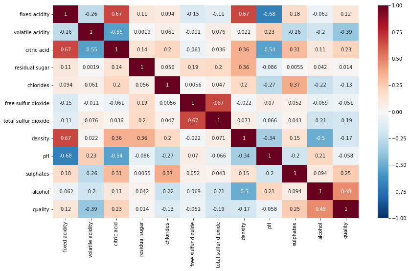

```python
#Plotting a Correlation Matrix using Heatmap

correlation = wine.corr() #compute correlation for all features in dataset

#plotting
plt.figure(figsize=(14, 8))  # set figure size
sns.heatmap(correlation, annot=True, linewidths=0, vmin=-1, vmax = +1, cmap="RdBu_r")
plt.show()
```

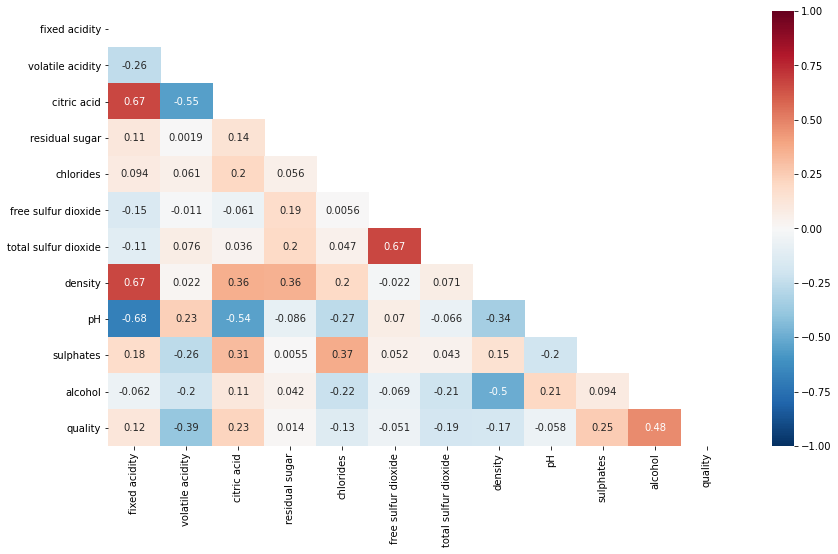

```python
import matplotlib.pyplot as plt
import seaborn as sns
%matplotlib inline

#Plotting a diagonal correlation matrix

correlation = wine.corr()  #compute correlation for all features in dataset
plt.figure(figsize=(14, 8)) # set figure size

# Generate a mask for the upper triangle
mask = np.triu(np.ones_like(correlation, dtype=np.bool))
#print(mask)

sns.heatmap(correlation, annot=True, linewidths=0, vmin=-1, vmax = +1, cmap="RdBu_r",mask=mask)
plt.show()
```

- `np.ones_like` : Return an array of ones with the same shape and type as a given array.
- `np.triu`: Upper triangle of an array.

Since `quality` variables seems to be a variable of major interest as it represent the Quality Rating given to a particular wine. Lets try to figure out what variables are related to `quality`.

```python
correlation['quality'].sort_values(ascending=False)
```

```
quality                 1.000000
alcohol                 0.476166
sulphates               0.251397
citric acid             0.226373
fixed acidity           0.124052
residual sugar          0.013732
free sulfur dioxide    -0.050656
pH                     -0.057731
chlorides              -0.128907
density                -0.174919
total sulfur dioxide   -0.185100
volatile acidity       -0.390558
Name: quality, dtype: float64
```